# Презентация к лабораторной работе 4

Выполнение

Власов Артем Сергеевич

1132246841@rudn.ru

Российский университет дружбы народов

# Информация

## Докладчик

- Власов Артем Сергеевич
- Студент
- Студент
- Российский университет дружбы народов им. П. Лумумбы
- 1132246841@rudn.ru
- https://vlasovas52.github.io/ru/

# Вводная часть

## Цели и задачи

Получить навыки работы с репозиториями и менеджерами пакетов. 1. Изучите,как и в каких файлах подключаются репозитории для установки программного обеспечения; изучите основные возможности (поиск,установка,обновление,удаление пакета,работа с историей действий) команды dnf 2. Изучите иповторите процесс установки/удаления определённого пакета с использованием возможностей dnf 3. Изучите иповторите процесс установки/удаления определённого пакета с использованием возможностей rpm

# Выполнение лабораторной работы 4

Переходим на учетную запись root, изучаем содержание файлов репозиториев.

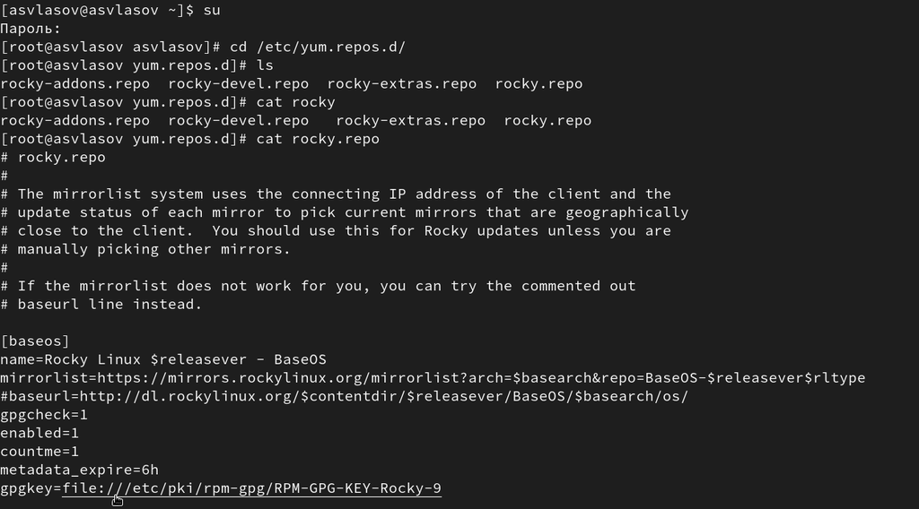

Репозитории

Выводим список репозиториев.

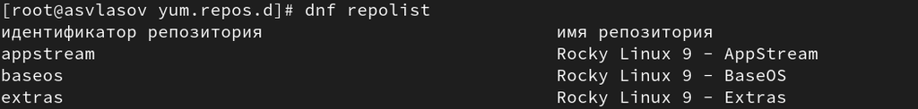

Список репозиториев

Выводим список всех пакетов, где есть слово user.

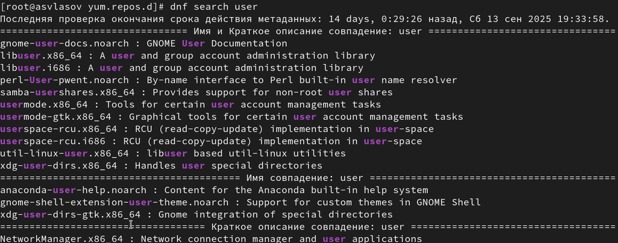

Пакеты user

Установка и удаление nmap.

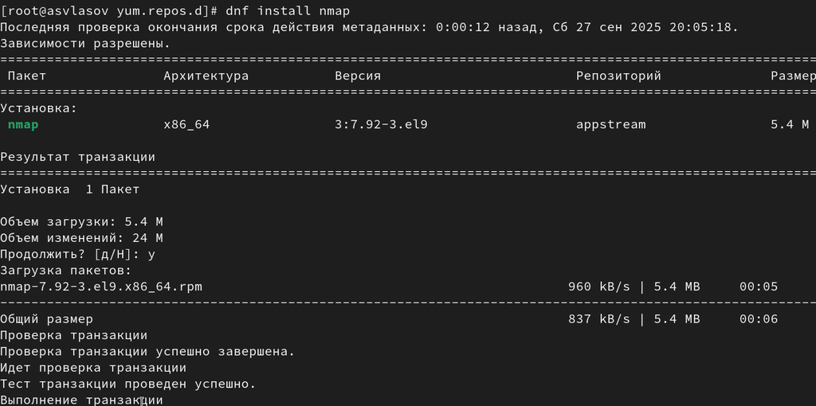

Установка пакета

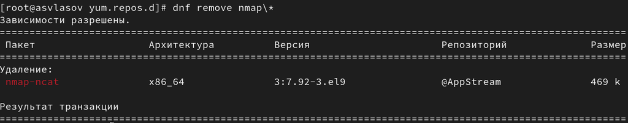

Удаление пакетов

Получим список имеющихся групп пакетов и установим rpm.

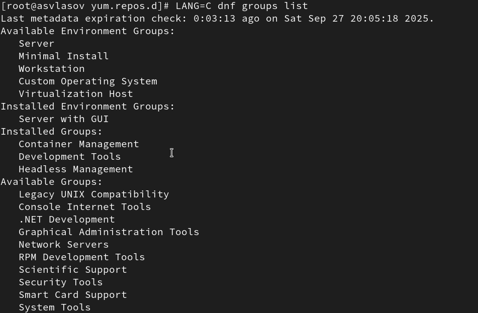

Список пакетов

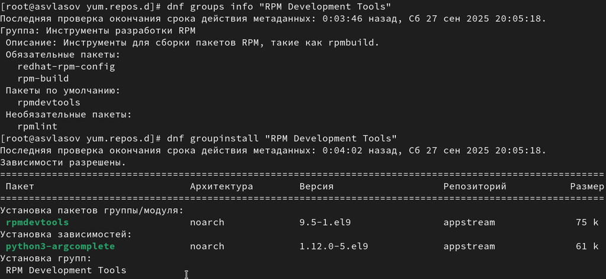

Установка rpm

Работа с историей команды dnf и отменой действия.

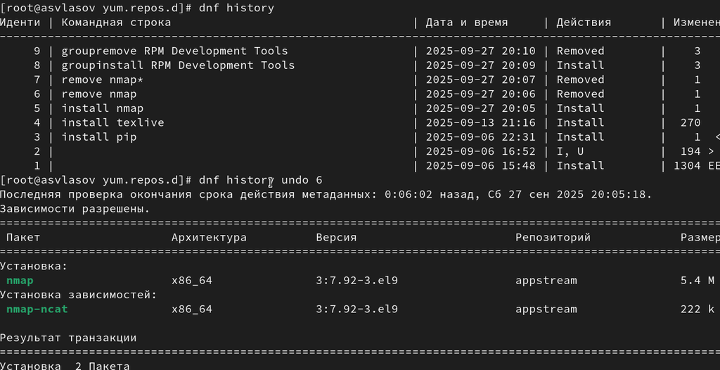

История и отмена команды

Работа с rpm (установка lynx), Поиск и установка rpm пакета.

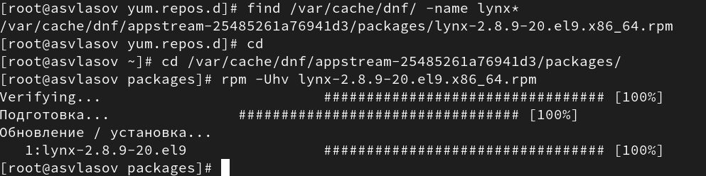

Установка пакета

Получение информации о файлах пакета lynx.

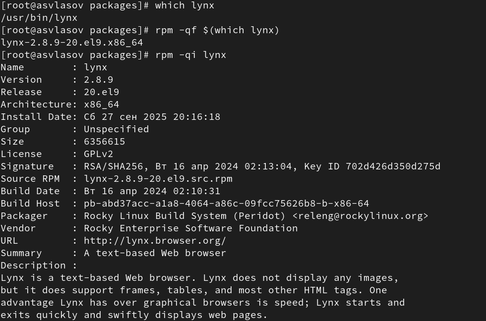

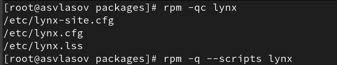

Расположение конфигурационных файлов и содержания скриптов

Работа с пакетом dnsmasq. Затем повторяем все действия и смотрим информацию о пакете.

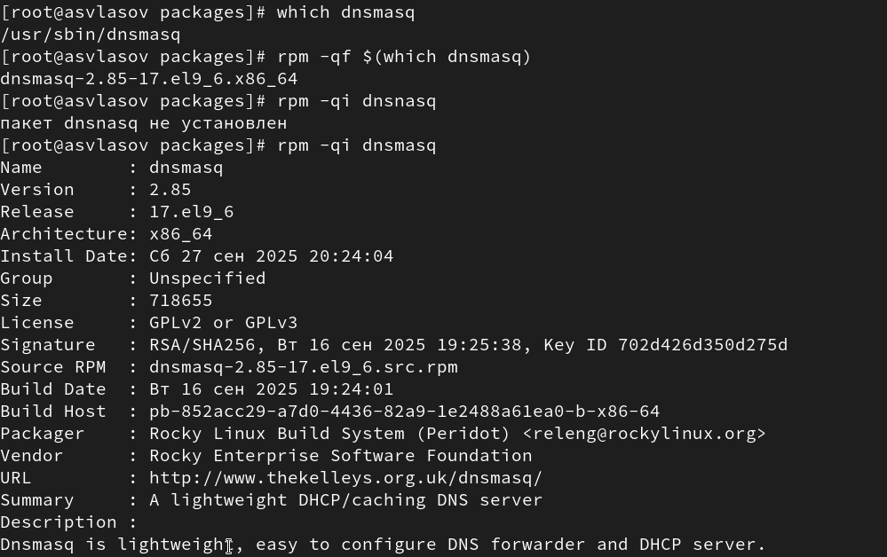

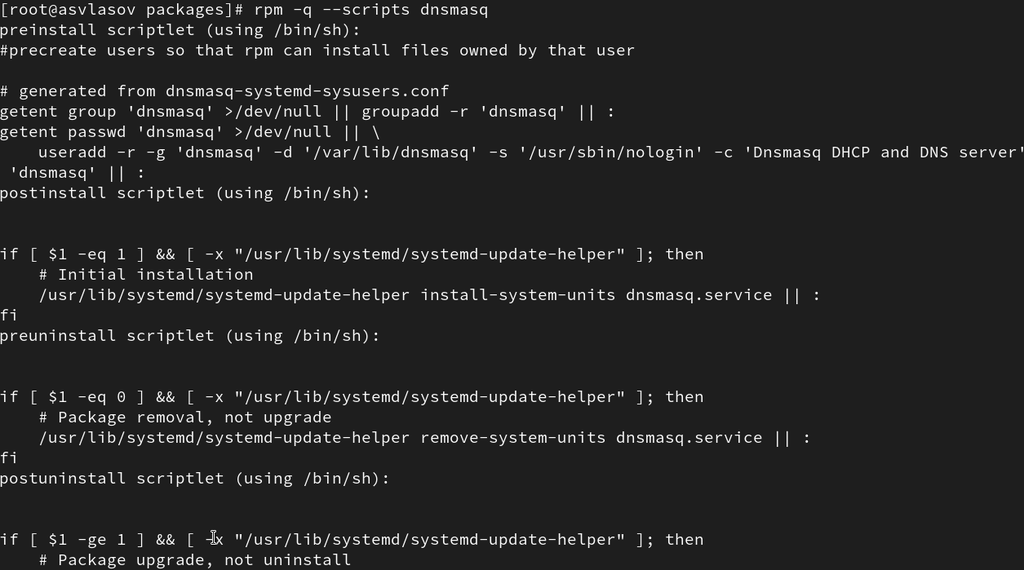

# Выводы

Мы получили навыки работы с репозиториями и менеджерами пакетов, выполнили задание и ответили на контрольные вопросы.